# texmex scratch

UKCEH; Adam Griffin

12/02/2020

# AquaCAT, Project 07441

This document investigates the `texmex` package, the netCDF files coming out of the G2G modelling, and what needs wrangling to get the data in a reasonable shape.

### Adjusted texmex functions

These functions allow the printing of one or two plots, not all the pairwise plots.

## Data

The data will come in 20-30 year periods on a daily time step (with possible difference in days/year). Data is in netCDF format, and is currently hosted on the linux network.

```r
if(substr(osVersion,1,3) == "Win"){
  data_wd <- "S:/run_hmfg2g/outputs/"
}else{
  data_wd <- "/prj/run_hmfg2g/outputs/"
}

#### Data -----------------------------------------------------------
ncname <- "dmflow_RCM01_198012_201011_out.nc" #2GB
ST <-  Sys.time()
ncin <- nc_open(paste0(data_wd,ncname))  # this is a huge file, do not open without reason.
print(Sys.time() - ST)
```

```
## Time difference of 3.309316 secs
```

```r
print(ncin)
```

```
## File S:/run_hmfg2g/outputs/dmflow_RCM01_198012_201011_out.nc (NC_FORMAT_NETCDF4):
##
##      1 variables (excluding dimension variables):
##         float dmflow[Easting,Northing,Time]   (Chunking: [700,1000,1])  (Compression: shuffle,level 5)
##             units: m3 s-1
##             standard_name: dmflow
##             long_name: Daily mean river flow
##             _FillValue: -999
##             missing_value: -999
##
##      3 dimensions:
##         Northing  Size:1000
##             standard_name: Northing
##             axis: Y
##             units: GB National Grid
##         Easting  Size:700
##             standard_name: Easting
##             axis: X
##             units: GB National Grid
##         Time  Size:10800   *** is unlimited ***
##             standard_name: Time
##             axis: T
##             units: days since 1961-1-1 0:0:0
##             calendar: 360_day
```

Here we just take a small sample from the dataset (25*25 gridpoints for 2000 days) to take a look. `NA` is sea pixels, `-1` is not on the river network.

```r
istart <- 390
Di <- 25
jstart <- 400
Dj <- 25
tstart <- 101
Dt <- 2000

ST <- Sys.time()
ncflow <- ncvar_get(ncin, varid="dmflow",
                    start=c(istart,jstart,101), count=c(Di,Dj,Dt))
print(Sys.time() - ST)
```

```
## Time difference of 2.363459 mins
```

```r
# for Di = 25, Dj = 25, Dt = 2000, ncflow is ~10MB

for(i in 1:5){
  v <- as.vector(ncflow[,,i])
  print(paste("Range:", max(v[!is.na(v) & v > -1]),
        min(v[!is.na(v) & v > -1])))
  print(paste("Number of -1s:", sum(v[!is.na(v)]==-1)))
  print(paste("Number of NAs:", sum(is.na(v))))
}
```

```
## [1] "Range: 4.78984260559082 0.177162930369377"
## [1] "Number of -1s: 581"
## [1] "Number of NAs: 0"
## [1] "Range: 4.50149488449097 0.173385798931122"
## [1] "Number of -1s: 581"
## [1] "Number of NAs: 0"
## [1] "Range: 4.58086204528809 0.169792115688324"
## [1] "Number of -1s: 581"
## [1] "Number of NAs: 0"
## [1] "Range: 4.8333888053894 0.167452678084373"
## [1] "Number of -1s: 581"
## [1] "Number of NAs: 0"
## [1] "Range: 4.33350896835327 0.131873935461044"
## [1] "Number of -1s: 581"
## [1] "Number of NAs: 0"
```

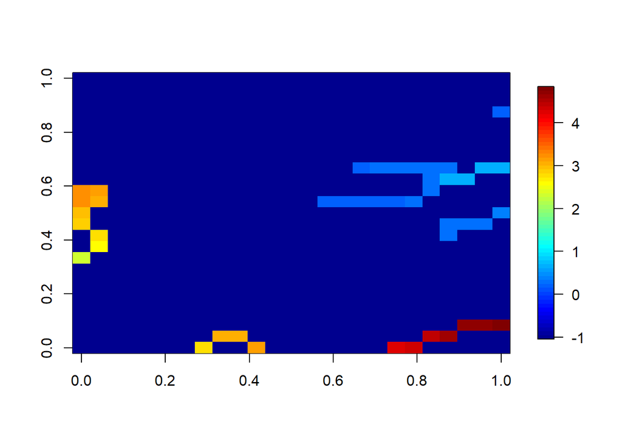

```r
image.plot(ncflow[,,1])
```

```r
ST <- Sys.time()
ncWide <- ncvar_get(ncin, varid="dmflow", start=c(1, 1, tstart),
                    count=c(-1, -1, 1))
print(Sys.time() - ST)
```

```
## Time difference of 0.08016706 secs
```

```r
v <- as.vector(ncWide)
print(paste("Range:", max(v[!is.na(v) & v > -1]),
        min(v[!is.na(v) & v > -1])))
```

```
## [1] "Range: 225.02262878418 0.0289440434426069"
```

```r
print(paste("Number of -1s:", sum(v[!is.na(v)]==-1)))
```

```
## [1] "Number of -1s: 208359"
```

```r
print(paste("Number of NAs:", sum(is.na(v))))
```

```
## [1] "Number of NAs: 471727"
```

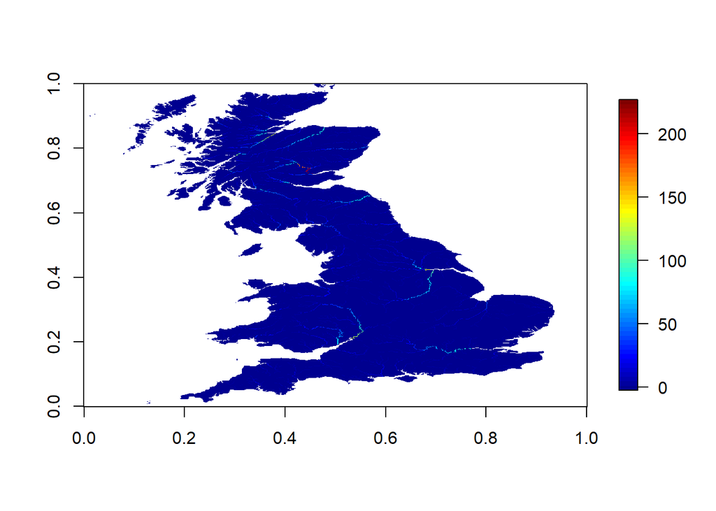

```r
image.plot(ncWide[,dim(ncWide)[2]:1])
```

## Event extraction

This will either be much more or much less in depth for the final dataset.

```r
HasData <- which(apply(ncflow, c(1,2),
                       function(v){sum(v[which(!is.na(v))] > -1) == Dt}),
                 arr.ind=T)
# HasData is important for gluing the events back in at the other end of the
# pipeline.

ncData <- matrix(NA, ncol=nrow(HasData), nrow=Dt)
for(i in 1:nrow(HasData)){
  ncData[,i] <- ncflow[HasData[i,1], HasData[i,2],]
}
```

For this, it is worth noting that for `is.na(v) & v > -1` we have `FALSE & NA == FALSE`.

## Using texmex

This section gives a quick overview of the main functions needed from texmex.

```r
ST <- Sys.time()
  mmex <- mex(ncData, mqu=.7, penalty="none", dqu=.7, which=2)
print(Sys.time() - ST)
```

```
## Time difference of 11.76327 secs
```

```r
ST <- Sys.time()
  myboot <- bootmex(mmex, R=10)  # R=10 is quite low.
```

```
## 10 replicates done
```

```r
print(Sys.time() - ST)
```

```
## Time difference of 1.58528 mins
```

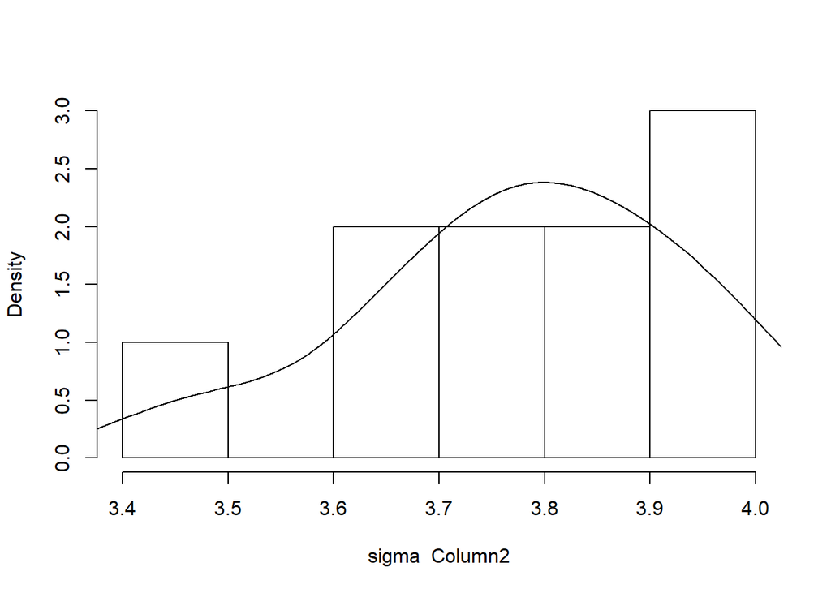

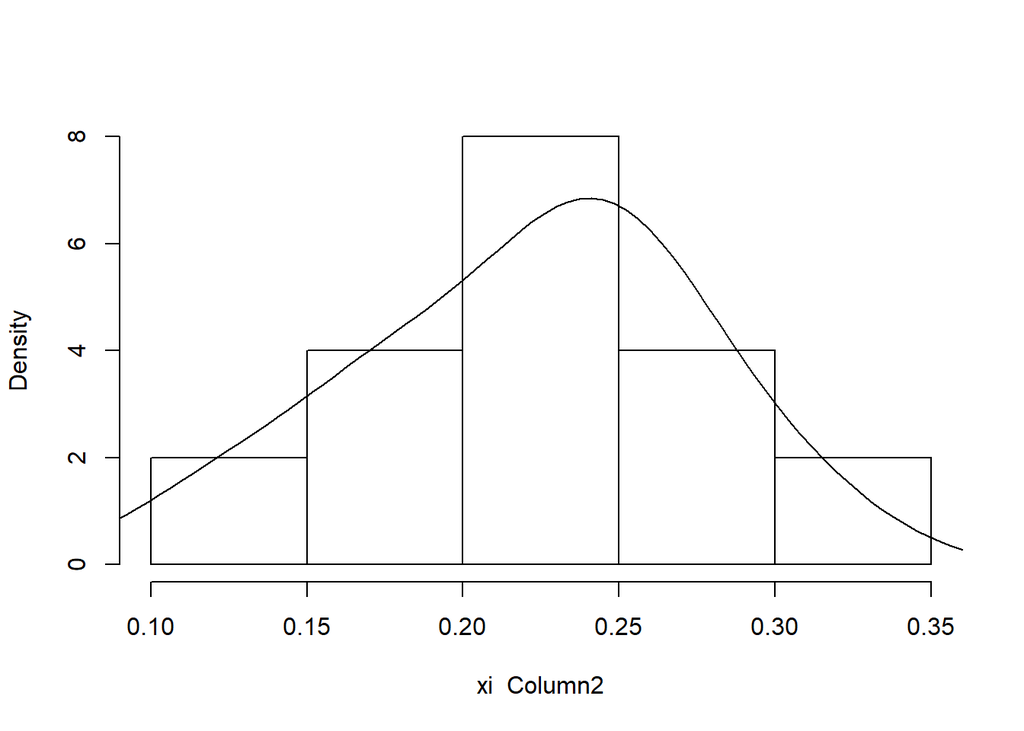

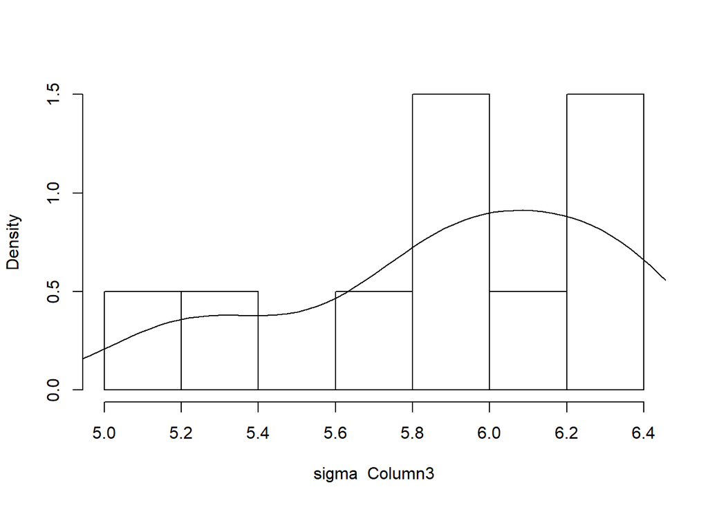

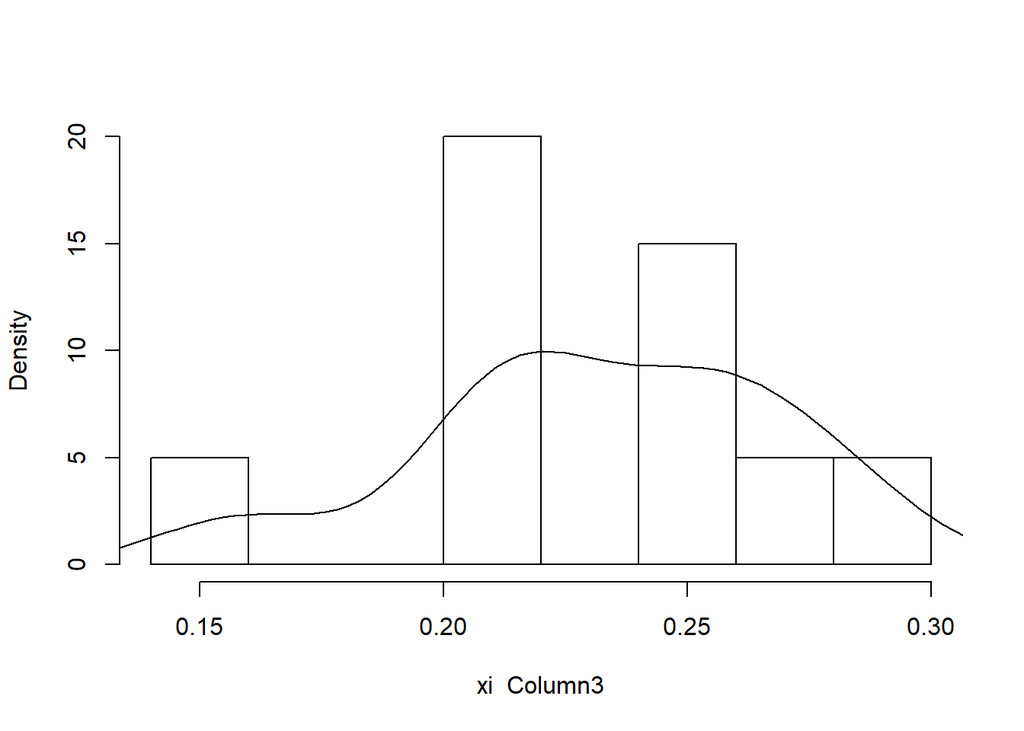

```r
plottexmex(myboot, plotnum=3:6)
```

```r
ST <- Sys.time()
mypred <- predict(myboot,  pqu=.99)
```

```
## 10 sets done
```

```r
print(Sys.time() - ST)
```

```
## Time difference of 17.22672 secs
```

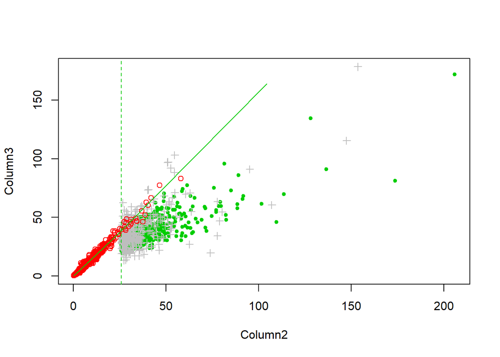

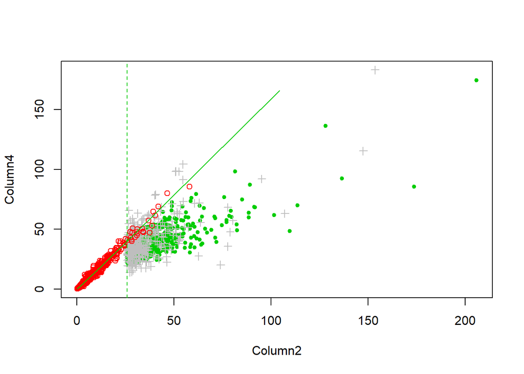

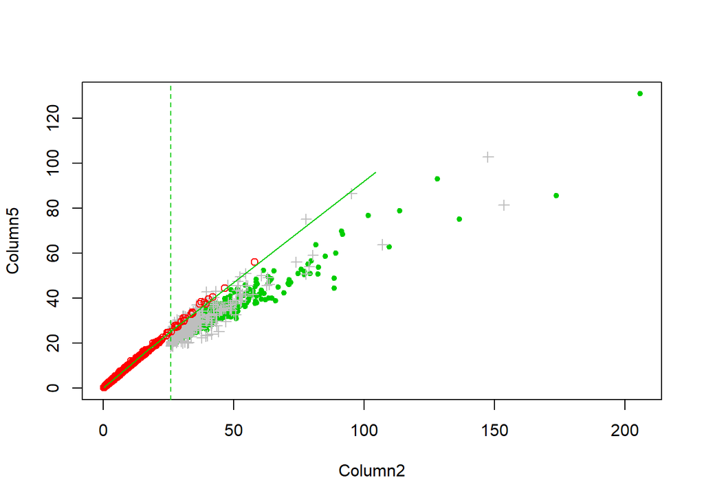

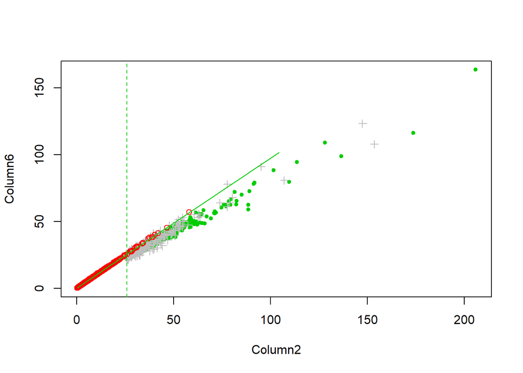

```r
plotpredmex(mypred, plotnum=3:6)
```

```r
summary(mypred, probs = c(0.025, 0.5, 0.975))
```

```
## predict.mex(object = myboot, pqu = 0.99)
##
## Results from 10 bootstrap runs.
##
## Conditioned on Column2 being above its 99th percentile.
##
##
## Conditional Mean and Quantiles:
##
##       Column2|Column2>Q99 Column1|Column2>Q99 Column3|Column2>Q99
## mean                35.30               26.00               45.10
## se                   3.73                3.99                4.31
## 2.5%                29.10               20.40               39.40
## 50%                 35.90               26.10               44.00
## 97.5%               40.30               32.40               52.70
##       Column4|Column2>Q99 Column5|Column2>Q99 Column6|Column2>Q99
## mean                47.20               28.90               32.80
## se                   4.66                3.07                4.22
## 2.5%                40.80               25.10               28.40
## 50%                 48.10               29.20               32.40
## 97.5%               53.30               33.40               40.80
##       Column7|Column2>Q99 Column8|Column2>Q99 Column9|Column2>Q99
## mean                48.70               49.60                58.0
## se                   3.39                3.26                10.6
## 2.5%                43.90               45.60                44.3
## 50%                 49.10               49.30                57.1
## 97.5%               53.90               56.00                76.5
##       Column10|Column2>Q99 Column11|Column2>Q99 Column12|Column2>Q99
## mean                 57.10                58.70                37.60
## se                    6.47                 5.72                 2.75
## 2.5%                 50.70                49.30                32.30
## 50%                  55.70                58.90                38.60
## 97.5%                67.30                67.60                40.50
##       Column13|Column2>Q99 Column14|Column2>Q99 Column15|Column2>Q99
## mean                 40.80                44.00                8.710
## se                    3.84                 5.92                0.841
## 2.5%                 35.30                34.90                7.050
## 50%                  40.80                43.40                8.840
## 97.5%                47.30                53.10                9.720
##       Column16|Column2>Q99 Column17|Column2>Q99 Column18|Column2>Q99
```

[output cut: 91 more lines]

```
##                                 1                               1
##  P(Column31>7.04477|Column2>Q99) P(Column32>0.957141|Column2>Q99)
##                                1                                1
##  P(Column33>1.00653|Column2>Q99) P(Column34>2.10243|Column2>Q99)
##                                1                               1
##  P(Column35>2.14245|Column2>Q99) P(Column36>0.79542|Column2>Q99)
##                                1                               1
##  P(Column37>0.831553|Column2>Q99) P(Column38>0.902107|Column2>Q99)
##                                 1                                1
##  P(Column39>0.96412|Column2>Q99) P(Column40>0.978576|Column2>Q99)
##                                1                                1
##  P(Column41>1.05943|Column2>Q99) P(Column42>2.18444|Column2>Q99)
##                                1                               1
##  P(Column43>2.21656|Column2>Q99) P(Column44>0.628155|Column2>Q99)
##                                1                                1
```

```r
MGPD <- migpd(ncData[,1:6], mqu=.7, penalty="none", maxit=1000)

mexdep <- mexDependence(MGPD, which=1, dqu=.7, margins="gumbel")
```

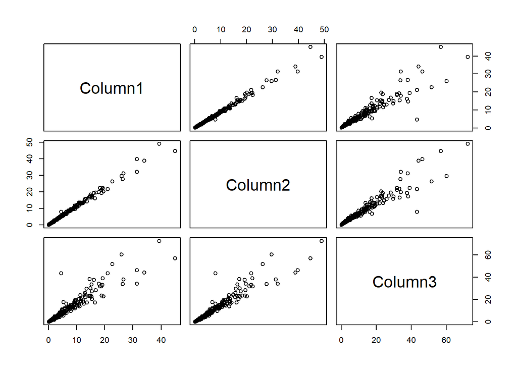

```r
#mall <- mexAll(ncData[,1:6], mqu=0.8, dqu=0.8)

res <- lapply(1:6, function(i) {
    mex(ncData[,1:6], which = i, mqu = 0.8, dqu = 0.8)
})
names(res) <- names(data)
oldClass(res) <- "mexList"


mmc <- mexMonteCarlo(500, res)
pairs(mmc$MCsample[,1:3])
```

Not sure what this means, but this is the text from plotting mex predict objects.

The plot method for class “predict.mex” displays both the original data and the simulated data generated above the threshold for prediction; it shows the threshold for prediction (vertical line) and also the curve joining equal quantiles of the marginal distributions – this is for reference: variables that are perfectly dependent will lie exactly on this curve. Original data are shown with one plotting character and simulated data with another; colours of simulated point distinguish those points which have the conditioning variable as the largest (on a quantile scale) or not the largest.